# All my homework

Xingyan Xu

2024-12-05

# 第一次作业

## 3.4题

The Rayleigh density [156, Ch. 18] is
$$f(x) = \frac{x}{\sigma^2}
e^{-\frac{x^2}{2\sigma^2}}, \quad x \geq 0, \, \sigma >
0.$$

Develop an algorithm to generate random samples from a Rayleigh($\sigma$) distribution. Generate Rayleigh($\sigma$) samples for several choices of $\sigma>0$ and check that the mode of the generated samples is close to the theoretical mode $\sigma$ (check the histogram).

解答过程: 先对密度积分
$$\int_{0}^{t}\frac{x}{\sigma^2}e^{-\frac{x^2}{2\sigma^2}}dx=-e^{-\frac{x^2}{2\sigma^2}}|_{0,t}=1-e^{-\frac{t^2}{2\sigma^2}}$$

因此令$u=1-e^{-\frac{t^2}{2\sigma^2}}$反解出$x=\sqrt{-2\sigma^2ln(1-u)}$，令u服从(0,1)上均匀分布即可构造出服从Rayleigh($\sigma$)分布的样本：

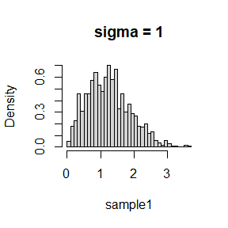

```r
# 设置参数
set.seed(0)
sigma <- c(1, 2, 3)
n <- 1000  # 每个σ生成1000个样本
sample1 <- sigma[1] * sqrt(-2 * log(runif(n)))
sample2 <- sigma[2] * sqrt(-2 * log(runif(n)))
sample3 <- sigma[3] * sqrt(-2 * log(runif(n)))

hist(sample1, breaks = 50, main = paste("sigma =", sigma[1]), probability = TRUE)
```

```r
generated_samples <- density(sample1)$x[which.max(density(sample1)$y)]
cat("众数是",generated_samples,"此时的sigma是",sigma[1])
```

```
## 众数是 1.275881 此时的sigma是 1
```

类似的还能对不同的sigma进行数据模拟:

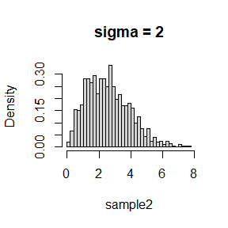

```
## 众数是 2.499344 此时的sigma是 2
```

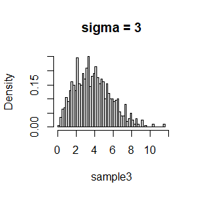

```
## 众数是 3.333107 此时的sigma是 3
```

从上述代码中可以发现众数跟真值$\sigma$比较接近

## 3.11

Generate a random sample of size 1000 from a normal location mixture. The components of the mixture have N(0,1) and N(3,1) distributions with mixing probabilities p1 and $p_2 =1− p_1$. Graph the histogram of the sample with density superimposed, for $p_1 =0.75$. Repeat with different values for $p_1$ and observe whether the empirical distribution of the mixture appears to be bimodal. Make a conjecture about the values of $p_1$ that produce bimodal mixtures.

解答过程：

p1 = 0.5时

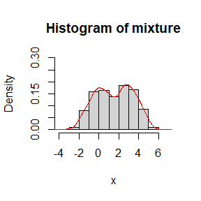

```r
set.seed(0)
n <- 1000
p <- c(0.5, 0.5)
k <- sample(0:1, size = n, replace = TRUE, prob = p)
x1 <- rnorm(n)
x2 <- rnorm(n, mean = 3, sd = 1)
x <- (1-k)*x1 + k*x2
hist(x, probability = TRUE, main="Histogram of mixture",
ylim = c(0,0.3))
lines(density(x), col = "red")
```

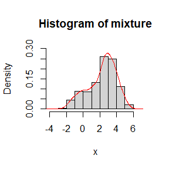

```r
set.seed(0)
n <- 1000
p <- c(0.25, 0.75)
k <- sample(0:1, size = n, replace = TRUE, prob = p)
x1 <- rnorm(n)
x2 <- rnorm(n, mean = 3, sd = 1)
x <- (1-k)*x1 + k*x2
hist(x, probability = TRUE, main="Histogram of mixture",
ylim = c(0,0.3))
lines(density(x), col = "red")
```

p1 = 0.75时

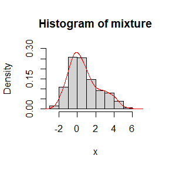

```r
set.seed(0)
n <- 1000
p <- c(0.75, 0.25)
k <- sample(0:1, size = n, replace = TRUE, prob = p)
x1 <- rnorm(n)
x2 <- rnorm(n, mean = 3, sd = 1)
x <- (1-k)*x1 + k*x2
hist(x, probability = TRUE, main="Histogram of mixture",
ylim = c(0,0.3))
lines(density(x), col = "red")
```

发现随着p1从0.5开始逐渐变小或者变大，峰从双峰逐渐变成单峰，这是因为此时两个正态分布中有一个逐渐占主导地位，因此在p1 = 0.5时双峰最明显，在p1靠近0或者1时逐渐变成单峰

## 3.14

A compound Poisson process is a stochastic process $\{X(t), t \geq 0\}$ that can be represented as the random sum
$$X(t) = \sum_{i=1}^{N(t)} Y_i, \quad t \geq 0,$$
where $\{N(t), t \geq 0\}$ is a Poisson process and $Y_1, Y_2, \dots$ are iid and independent of $\{N(t), t \geq 0\}$. Write a program to simulate a compound Poisson $(\lambda)$–Gamma process (Y has a Gamma distribution). Estimate the mean and the variance of $X(10)$ for several choices of the parameters and compare with the theoretical values.

Hint: Show that
$$E[X(t)] = \lambda t E[Y_1] \quad \text{and} \quad \text{Var}(X(t)) =
\lambda t E[Y_1^2].$$

解答过程：Gamma分布参数为(1,1)，泊松分布参数$\lambda=1$时：

```r
# 设定参数
lambda <- 1  # 泊松过程的强度参数
shape <- 1
rate <- 1    # Gamma分布的两个参数
t <- 10      # 观察时间

# 定义复合泊松-伽马过程的模拟函数
compound_poisson_gamma <- function(lambda, shape, rate, t) {
  # 泊松过程：确定给定时间t的事件数
  N_t <- rpois(1, lambda * t)

  # 如果事件数为0，返回0，否则生成Gamma随机变量
  if (N_t == 0) {
    return(0)
  } else {
    Y <- rgamma(N_t, shape = shape, rate = rate)  # 生成N_t个Gamma随机变量
    return(sum(Y))  # 返回随机和
  }
}

# 模拟过程
n_simulations <- 10000  # 模拟次数
X_10 <- replicate(n_simulations, compound_poisson_gamma(lambda, shape, rate, t))

# 计算样本均值和方差
mean_X_10 <- mean(X_10)
var_X_10 <- var(X_10)

# 理论均值和方差
theoretical_mean <- lambda * t * (shape / rate)
theoretical_variance <- lambda * t * ((shape / rate^2) + (shape/rate)^2)

# 输出结果
cat("Sample mean of X(10):", mean_X_10, "\n")
```

```
## Sample mean of X(10): 10.0062
```

```r
cat("Sample variance of X(10):", var_X_10, "\n")
```

```
## Sample variance of X(10): 19.84671
```

```r
cat("Theoretical mean of X(10):", theoretical_mean, "\n")
```

```
## Theoretical mean of X(10): 10
```

```r
cat("Theoretical variance of X(10):", theoretical_variance, "\n")
```

```
## Theoretical variance of X(10): 20
```

Gamma分布参数为(2,2)，泊松分布参数$\lambda=1$时：

```r
# 设定参数
lambda <- 1  # 泊松过程的强度参数
shape <- 2
rate <- 2    # Gamma分布的两个参数
t <- 10      # 观察时间

# 定义复合泊松-伽马过程的模拟函数
compound_poisson_gamma <- function(lambda, shape, rate, t) {
  # 泊松过程：确定给定时间t的事件数
  N_t <- rpois(1, lambda * t)

  # 如果事件数为0，返回0，否则生成Gamma随机变量
  if (N_t == 0) {
    return(0)
  } else {
    Y <- rgamma(N_t, shape = shape, rate = rate)  # 生成N_t个Gamma随机变量
    return(sum(Y))  # 返回随机和
  }
}

# 模拟过程
n_simulations <- 10000  # 模拟次数
X_10 <- replicate(n_simulations, compound_poisson_gamma(lambda, shape, rate, t))

# 计算样本均值和方差
mean_X_10 <- mean(X_10)
var_X_10 <- var(X_10)

# 理论均值和方差
theoretical_mean <- lambda * t * (shape / rate)
theoretical_variance <- lambda * t * ((shape / rate^2) + (shape/rate)^2)

# 输出结果
cat("Sample mean of X(10):", mean_X_10, "\n")
```

```
## Sample mean of X(10): 9.99486
```

```r
cat("Sample variance of X(10):", var_X_10, "\n")
```

```
## Sample variance of X(10): 15.48726
```

```r
cat("Theoretical mean of X(10):", theoretical_mean, "\n")
```

```
## Theoretical mean of X(10): 10
```

```r
cat("Theoretical variance of X(10):", theoretical_variance, "\n")
```

```
## Theoretical variance of X(10): 15
```

Gamma分布参数为(2,2)，泊松分布参数$\lambda=2$时：

```r
# 设定参数
lambda <- 2  # 泊松过程的强度参数
shape <- 2
rate <- 2    # Gamma分布的两个参数
t <- 10      # 观察时间

# 定义复合泊松-伽马过程的模拟函数
compound_poisson_gamma <- function(lambda, shape, rate, t) {
  # 泊松过程：确定给定时间t的事件数
  N_t <- rpois(1, lambda * t)

  # 如果事件数为0，返回0，否则生成Gamma随机变量
  if (N_t == 0) {
    return(0)
  } else {
    Y <- rgamma(N_t, shape = shape, rate = rate)  # 生成N_t个Gamma随机变量
    return(sum(Y))  # 返回随机和
  }
}

# 模拟过程
n_simulations <- 10000  # 模拟次数
X_10 <- replicate(n_simulations, compound_poisson_gamma(lambda, shape, rate, t))

# 计算样本均值和方差
mean_X_10 <- mean(X_10)
var_X_10 <- var(X_10)

# 理论均值和方差
theoretical_mean <- lambda * t * (shape / rate)
theoretical_variance <- lambda * t * ((shape / rate^2) + (shape/rate)^2)

# 输出结果
cat("Sample mean of X(10):", mean_X_10, "\n")
```

```
## Sample mean of X(10): 19.99826
```

```r
cat("Sample variance of X(10):", var_X_10, "\n")
```

```
## Sample variance of X(10): 30.30163
```

```r
cat("Theoretical mean of X(10):", theoretical_mean, "\n")
```

```
## Theoretical mean of X(10): 20
```

```r
cat("Theoretical variance of X(10):", theoretical_variance, "\n")
```

```
## Theoretical variance of X(10): 30
```

可以发现在无论参数如何变化，$X(10)$的理论均值和方差均与实验模拟的均值和方差接近

# 第二次作业

## 5.4

Write a function to compute a Monte Carlo estimate of the $Beta(3, 3)$ cdf, and use the function to estimate $F(x)$ for$x =0.1,0.2,...,0.9$. Compare the estimates with the values returned by the pbeta function in R.

```r
set.seed(0)
# 使用接受拒绝法生成 n 个服从 Beta(3,3) 分布的样本
accept_reject_beta <- function(n) {
  # 初始化接受的样本集合
  accepted_samples <- numeric(n)

  # Beta(3,3) 的目标密度函数（未归一化）
  target_density <- function(x) {
    return(x^2 * (1 - x)^2)
  }

  # 设定常数 c (选择较大的 c 可以提高接受概率)
  c <- 1.5  # 因为 Beta(3,3) 的最大密度值约为 1.5

  # 计数已接受的样本数
  count <- 0

  # 开始接受拒绝过程
  while (count < n) {
    # 从均匀分布 U(0,1) 中生成候选样本
    x_candidate <- runif(1)

    # 生成一个 U(0, 1) 的随机数作为接受标准
    u <- runif(1)

    # 根据接受概率决定是否接受候选样本
    if (u <= target_density(x_candidate) / c) {
      # 接受该候选样本
      count <- count + 1
      accepted_samples[count] <- x_candidate
    }
  }

  return(accepted_samples)
}

# 定义蒙特卡洛估计函数，使用接受拒绝法生成 Beta(3,3) 样本
monte_carlo_beta_cdf <- function(x, n = 100000) {
  # 使用接受拒绝法生成 n 个 Beta(3, 3) 分布的随机样本
  samples <- accept_reject_beta(n)
  # 计算 F(x) = P(X <= x)，使用向量化比较
  cdf_estimates <- colMeans(outer(samples, x, "<="))
  return(cdf_estimates)
}

# 给定的 x 值
x_values <- seq(0.1, 0.9, by = 0.1)

# 使用蒙特卡洛方法计算 CDF
monte_carlo_estimates <- monte_carlo_beta_cdf(x_values)

# 使用 R 自带的 pbeta 函数计算真实的 CDF
pbeta_estimates <- pbeta(x_values, 3, 3)

# 打印结果并比较
results <- data.frame(x = x_values,
                      MonteCarlo = monte_carlo_estimates,
                      pbeta = pbeta_estimates)

print(results)
```

```
##     x MonteCarlo   pbeta
## 1 0.1    0.00781 0.00856
## 2 0.2    0.05702 0.05792
## 3 0.3    0.16251 0.16308
## 4 0.4    0.31740 0.31744
## 5 0.5    0.50171 0.50000
## 6 0.6    0.68351 0.68256
## 7 0.7    0.83781 0.83692
## 8 0.8    0.94251 0.94208
## 9 0.9    0.99158 0.99144
```

可以从表中看出估计的cdf与真值比较接近，实际上在样本量趋于无穷时估计是相合的

## 5.9

The Rayleigh density [156, (18.76)] is given by

$$f(x) = \frac{x}{\sigma^2}
e^{-\frac{x^2}{2\sigma^2}}, \quad x \geq 0, \sigma > 0.$$

Implement a function to generate samples from a $Rayleigh(\sigma)$ distribution using antithetic variables. What is the percent reduction in variance of $\frac{X + X'}{2}$ compared with $\frac{X_1 + X_2}{2}$ for independent $(X_1, X_2)$?

最后计算方差减少的百分比:

```r
set.seed(0)

# 设置Rayleigh分布的sigma参数
sigma <- 1
# 设置样本数量
n <- 1000

# 生成n个独立的Rayleigh分布样本
U1 <- runif(n)  # 生成均匀分布的随机变量
U2 <- runif(n)  # 生成另一个独立的均匀分布随机变量
X1 <- sigma * sqrt(-2 * log(U1))  # 生成第一个Rayleigh样本
X2 <- sigma * sqrt(-2 * log(U2))  # 生成第二个独立Rayleigh样本


# 使用对偶变量生成n个Rayleigh分布样本
U <- runif(n)  # 生成均匀分布的随机变量
U_prime <- 1 - U  # 对偶变量
X <- sigma * sqrt(-2 * log(U))  # 生成Rayleigh样本
X_prime <- sigma * sqrt(-2 * log(U_prime))  # 生成对偶的Rayleigh样本

# 生成独立变量样本和对偶变量样本
independent_samples <- (X1 + X2) / 2
antithetic_samples <- (X + X_prime) / 2

# 计算独立变量的方差和对偶变量的方差
var_independent <- var(independent_samples)
var_antithetic <- var(antithetic_samples)

# 计算方差减少的百分比
reduction_percent <- 100 * (var_independent - var_antithetic) / var_independent

cat("方差减少的百分比:", reduction_percent, "%\n")
```

```
## 方差减少的百分比: 94.83453 %
```

可以看出方差确实降低很多

## 5.13

Find two importance functions $f_1$ and $f_2$ that are supported on $(1, \infty)$ and are ‘close’ to
$$g(x) = \frac{x^2}{\sqrt{2\pi}} e^{-x^2/2}, \quad x > 1.$$
Which of your two importance functions should produce the smaller variance in estimating
$$\int_{1}^{\infty} \frac{x^2}{\sqrt{2\pi}} e^{-x^2/2} \, dx$$
by importance sampling? Explain.

令 $f_1(x) = c_1x e^{-x^2/2}, \quad x > 1$

其中$c_1$为归一化参数,$c_1=1/\int_{1}^{+\infty}xe^{-\frac{x^2}{2}}dx=1.6487$，保留四位小数

再令 $f_2(x) = c_2 e^{-x},\quad x>1$，同样$c_2$是归一化常数，$c_2=e=2.7183$

我们注意到重要性函数越接近目标分布，方差越小。因此我们预测$f_1(x) = c_1x e^{-x^2/2}, \quad x > 1$ 将会产生较小的方差。

最后，我们进行实验验证猜测：

```r
set.seed(0)

c1 <- 1.6487
c2 <- 2.7183

# 从重要性函数 f1 和 f2中抽样
samples1 <- function(n) {
  u <- runif(n, 0, 1)
  return(sqrt(-2*log(exp(-0.5)-u/c1)))
}

samples2 <- function(n) {
  u <- runif(n, 0, 1)
  return(1-log(1-u))
}

# 生成样本
n <- 10000  # 样本数量

# 从 f1 生成样本
samples_f1 <- samples1(n)

# 从 f2 生成样本
samples_f2 <- samples2(n)

# 计算重要性权重
weights_f1 <- samples_f1*c1/sqrt(2*pi)  # 计算 f1 的权重
weights_f2 <- samples_f2^2/sqrt(2*pi)*exp(-samples_f2^2/2)/exp(-samples_f2)  # 计算 f2 的权重

# 计算期望估计
estimate_f1 <- mean(weights_f1)
estimate_f2 <- mean(weights_f2)

# 计算方差
variance_f1 <- var(weights_f1)
variance_f2 <- var(weights_f2)

# 输出结果
cat("估计值 f1:", estimate_f1, "\n")
```

```
## 估计值 f1: 1.090849
```

```r
cat("估计值 f2:", estimate_f2, "\n")
```

```
## 估计值 f2: 1.089945
```

```r
cat("方差 f1:", variance_f1, "\n")
```

```
## 方差 f1: 0.1139113
```

```r
cat("方差 f2:", variance_f2, "\n")
```

```
## 方差 f2: 0.1844155
```

可以发现确实方法1的方差小一些

## Monte Carlo experiment

- For $n = 104,2×104,4×104,6×104,8×104$, apply the fast sorting algorithm to randomly permuted numbers of 1,…,n.
- Calculate computation time averaged over 100 simulations, denoted by $a_n$.
- Regress an on $t_n := nlog(n)$, and graphically show the results (scatter plot and regression line)

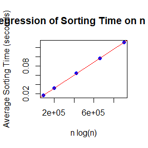

```r
# 快速排序函数
quick_sort <- function(arr) {
  if (length(arr) <= 1) {
    return(arr)
  } else {
    pivot <- arr[1]  # 基准
    left <- arr[arr < pivot]  # 左边部分
    right <- arr[arr > pivot]  # 右边部分
    middle <- arr[arr == pivot]  # 相等部分
    return(c(quick_sort(left), middle, quick_sort(right)))
  }
}

# 进行 Monte Carlo 实验
set.seed(123)  # 为了结果可重复

# 定义 n 的取值
n_values <- c(10^4, 2*10^4, 4*10^4, 6*10^4, 8*10^4)

# 保存平均时间的向量
avg_times <- c()

# 对每个 n 进行 100 次排序
for (n in n_values) {
  times <- numeric(100)  # 保存100次排序时间
  for (i in 1:100) {
    random_numbers <- sample(1:n)  # 生成随机排列的数字
    start_time <- Sys.time()  # 开始时间
    sorted_numbers <- quick_sort(random_numbers)  # 快速排序
    end_time <- Sys.time()  # 结束时间
    times[i] <- as.numeric(end_time - start_time, units = "secs")  # 计算排序耗时
  }
  avg_times <- c(avg_times, mean(times))  # 计算平均时间
}

# 将 n 和 log(n) 结合起来
log_n <- n_values * log(n_values)

# 进行回归分析
regression <- lm(avg_times ~ log_n)

# 可视化回归结果
plot(log_n, avg_times, main = "Regression of Sorting Time on n log(n)",
     xlab = "n log(n)", ylab = "Average Sorting Time (seconds)",
     pch = 19, col = "blue")
abline(regression, col = "red")
```

观察回归结果发现时间大概是O(nlog(n))级别

# 第三次作业

## 6.6

Estimate the 0.025, 0.05, 0.95, and 0.975 quantiles of the skewness $\sqrt{b_1}$ under normality by a Monte Carlo experiment. Compute the standard error of the estimates from (2.14) using the normal approximation for the density (with exact variance formula). Compare the estimated quantiles with the quantiles of the large sample approximation $\sqrt{b_1} ≈ N(0,6/n)$

题目即通过蒙特卡洛实验估计偏度$\sqrt{b_1}$的分位数（0.025, 0.05, 0.95, 0.975）

```r
# 设置随机种子以确保结果可重复
set.seed(0)

# 蒙特卡洛实验参数
n <- 1000  # 每次实验的样本大小
num_simulations <- 10000  # 总实验次数

# 存储偏度的平方根
skewness_sqrt_b1 <- numeric(num_simulations)

# 进行蒙特卡洛实验
for (i in 1:num_simulations) {
  # 生成 n 个正态分布的随机样本
  sample <- rnorm(n)

  # 计算样本偏度
  skewness_b1 <- sum((sample - mean(sample))^3) / ((n - 1) * sd(sample)^3)

  # 计算偏度的平方根并存储
  skewness_sqrt_b1[i] <- skewness_b1
}

# 计算所需的分位数
quantiles <- quantile(skewness_sqrt_b1, probs = c(0.025, 0.05, 0.95, 0.975))
print(quantiles)
```

```
##       2.5%         5%        95%      97.5%
## -0.1500782 -0.1277768  0.1294921  0.1542565
```

```r
# 计算标准误差
q_probs <- c(0.025, 0.05, 0.95, 0.975)
standard_errors <- sqrt(q_probs * (1 - q_probs) / (n * dnorm(qnorm(q_probs))^2))
print(standard_errors)
```

```
## [1] 0.08447427 0.06682486 0.06682486 0.08447427
```

```r
# 估计的标准差与正态分布近似的分位数
estimated_quantiles <- qnorm(q_probs, mean = 0, sd = sqrt(6/n))
print(estimated_quantiles)
```

```
## [1] -0.1518182 -0.1274098  0.1274098  0.1518182
```

```r
# 比较结果
comparison <- data.frame(Quantiles = c(0.025, 0.05, 0.95, 0.975),
                         Monte_Carlo = quantiles,
                         Standard_Error = standard_errors,
                         Normal_Approximation = estimated_quantiles)
print(comparison)
```

```
##       Quantiles Monte_Carlo Standard_Error Normal_Approximation
## 2.5%      0.025  -0.1500782     0.08447427           -0.1518182
## 5%        0.050  -0.1277768     0.06682486           -0.1274098
## 95%       0.950   0.1294921     0.06682486            0.1274098
## 97.5%     0.975   0.1542565     0.08447427            0.1518182
```

## 6.B

Tests for association based on Pearson product moment correlation $\rho$,Spearman’s rank correlation coefficient ρs, or Kendall’s coefficient $\tau$, are implemented in cor.test. Show (empirically) that the nonparametric tests based on $\rho_s$ or $\tau$ are less powerful than the correlation test when the sampled distribution is bivariate normal. Find an example of an alternative (a bivariate distribution (X,Y) such that X and Y are dependent) such that at least one of the nonparametric tests have better empirical power than the correlation test against this alternative.

```r
# 设置随机种子以便重现
set.seed(2)

# 设定参数
n <- 100  # 样本大小
num_simulations <- 1000  # 模拟次数

# 正态分布数据
pearson_results <- numeric(num_simulations)
spearman_results <- numeric(num_simulations)

for (i in 1:num_simulations) {
  # 生成双变量正态分布数据
  x <- runif(n, 0, 1)
  y <- x/2 + rt(n, df = 1)  # 让x和y相关，且相关性不高
  # 皮尔逊检验
  pearson_test <- cor.test(x, y)
  pearson_results[i] <- ifelse(pearson_test$p.value < 0.05, 1, 0)

  # 斯皮尔曼检验
  spearman_test <- cor.test(x, y, method = "spearman")
  spearman_results[i] <- ifelse(spearman_test$p.value < 0.05, 1, 0)
}

# 计算功效
pearson_power <- mean(pearson_results)
spearman_power <- mean(spearman_results)

cat("Bivariate Normal Distribution:\n")
```

```
## Bivariate Normal Distribution:
```

```r
cat("Pearson Power:", pearson_power, "\n")
```

```
## Pearson Power: 0.033
```

```r
cat("Spearman Power:", spearman_power, "\n")
```

```
## Spearman Power: 0.115
```

可以发现在x取0~1上均匀分布，y取$x/2$加上一个$t_1$分布时，Spearman检验的效能高于Pearson检验

## 补充问题

If we obtain the powers for two methods under a particular simulation setting with 10,000 experiments: say, 0.651 for one method and 0.676 for another method. We want to know if the powers are different at 0.05 level.

- What is the corresponding hypothesis test problem?
- What test should we use? Z-test, two-sample t-test, paired-t test or McNemar test? Why?
- Please provide the least necessary information for hypothesis testing

零假设: 两个方法的功效相等 $H_0: p_1=p_2$

对立假设: 两个方法的功效不同 $H_1: p_1\neq p_2$

在这种情况下，Z检验是最合适的检验方法。这是因为我们是在比较两个独立的比例（两个方法的功效），因此成对t检验和McNemar检验都不合适，同时每个方法的功效估计可以看作是来自大量实验（10,000 次）的样本比例，这符合对比例的正态近似，使用两样本t检验会使检验的功效降低

从题目条件可以看出$n_1=n_2=n=10000$为每个方法的实验次数，$p_1=0.651$为方法一的功效，$p_2=0.676$为方法二的功效。Z统计量可以通过以下公式计算：
$$Z=\frac{p_1-p_2}{SE}$$

其中$SE=\sqrt{\frac{p_1(1-p_1)}{n_1}+\frac{p_2(1-p_2)}{n_2}}=0.00668$

则$|Z|=3.7425>1.96$，因此拒绝原假设，认为两个方法的功效存在显著差异

# 第四次作业

# 第一题

Of N =1000 hypotheses, 950 are null and 50 are alternative. The p-value under any null hypothesis is uniformly distributed (use runif), and the p-value under any alternative hypothesis follows the beta distribution with parameter 0.1 and 1 (use rbeta). Obtain Bonferroni adjusted p-values and B-H adjusted p-values. Calculate FWER, FDR, and TPR under nominal level α =0.1 for each of the two adjustment methods based on m=10000 simulation replicates. You should output the 6 numbers (3 ) to a 3×2 table (column names: Bonferroni correction, B-H correction; row names: FWER, FDR, TPR). Comment the results.

```r
# 设置参数
set.seed(123)
N <- 1000           # 总假设数量
m <- 10000          # 模拟重复次数
alpha <- 0.1        # 显著性水平

# 初始化结果
results <- matrix(0, nrow = 3, ncol = 2)
colnames(results) <- c("Bonferroni correction", "B-H correction")
rownames(results) <- c("FWER", "FDR", "TPR")

# 模拟过程
for (i in 1:m) {
  # 生成 p-values
  p_values <- c(runif(950), rbeta(50, 0.1, 1))

  # 对p值进行两种调整
  B_H <- p.adjust(p_values, method = "BH")
  Bonferroni <- p.adjust(p_values, method = "bonferroni")

  # 计算TP、FP等指标
  reject_Bonferroni <- Bonferroni < alpha
  reject_B_H <- B_H < alpha
  true <- c(rep(FALSE, 950), rep(TRUE, 50))   # 标记真实备择假设


  # 计算FWER
  FP_Bonferroni <- sum(reject_Bonferroni & !true)     # 错误拒绝次数
  if((FP_Bonferroni > 0)){
    results["FWER", "Bonferroni correction"] <- results["FWER", "Bonferroni correction"] + 1/m
  }
  FP_B_H <- sum(reject_B_H & !true)
  if(FP_B_H > 0){
    results["FWER", "B-H correction"] <- results["FWER", "B-H correction"] + 1/m
  }

  # 计算FDR
  results["FDR", "Bonferroni correction"] <- results["FDR", "Bonferroni correction"] + (FP_Bonferroni / max(1, sum(reject_Bonferroni)))/m
  results["FDR", "B-H correction"] <- results["FDR", "B-H correction"] + (FP_B_H / max(1, sum(reject_B_H)))/m

  # 计算TPR
  TP_Bonferroni <- sum(reject_Bonferroni & true)      # Bonferroni正确拒绝次数
  TP_B_H <- sum(reject_B_H & true)              # B_H正确拒绝次数
  results["TPR", "Bonferroni correction"] <- results["TPR", "Bonferroni correction"] + (TP_Bonferroni / 50)/m
  results["TPR", "B-H correction"] <- results["TPR", "B-H correction"] + (TP_B_H / 50)/m
}

print(results)
```

```
##      Bonferroni correction B-H correction
## FWER           0.087300000     0.93050000
## FDR            0.004510088     0.09502215
## TPR            0.396736000     0.56106200
```

- FWER（Family-Wise Error Rate）:Bonferroni校正的FWER为0.0873，接近设定的显著性水平0.1。B-H校正的FWER为0.9305，表明它会更宽松地拒绝零假设，因此更容易产生至少一个假阳性。
- FDR（False Discovery Rate）:Bonferroni校正的FDR极低（0.0045），表明它在控制错误发现率上非常保守。B-H校正的FDR较高（0.095），即使假阳性率高，但它的目标就是控制在指定的错误发现率范围内。
- TPR（True Positive Rate）: Bonferroni校正的TPR为0.3967，表明它较难检测到真正的效应。B-H校正的TPR为0.561，意味着它能检测到更多的真正效应。

综合来看，B-H校正更适合在希望保持较高的检出率时使用，而Bonferroni校正则更加保守，适合严格控制假阳性率的场合

# EX7.4

Refer to the air-conditioning data set aircondit provided in the boot package. The 12 observations are the times in hours between failures of air conditioning equipment:
$$3, 5, 7, 18,
43, 85, 91, 98, 100, 130, 230, 487$$

Assume the times between failures follow an exponential distribution $\text{Exp}(\lambda)$. Obtain the MLE of the hazard rate λ and use bootstrap to estimate the bias and standard error of the estimate.

解答：对于一个指数分布 $\text{Exp}(\lambda)$, 似然函数为:

$$L(\lambda) = \prod_{i=1}^{n} \lambda e^{-\lambda x_i} = \lambda^n
e^{-\lambda \sum_{i=1}^{n} x_i}$$

将似然函数取对数:

$$\ell(\lambda) = n \log(\lambda) - \lambda \sum_{i=1}^{n} x_i$$

最大化似然函数可解出 $\lambda$:

$$\hat{\lambda} = \frac{n}{\sum_{i=1}^{n} x_i}$$

接下来是代码部分：

```r
# 加载boot包
library(boot)

set.seed(123)
# 数据集
data <- c(3, 5, 7, 18, 43, 85, 91, 98, 100, 130, 230, 487)

# 计算最大似然估计MLE
lambda_mle <- length(data) / sum(data)
lambda_mle
```

```
## [1] 0.00925212
```

```r
# 定义一个函数来计算MLE
lambda_mle_func <- function(data, index) {
  sample_data <- data[index]
  return(length(sample_data) / sum(sample_data))
}

# 使用boot函数进行bootstrap抽样，计算偏差和标准差
result <- boot(data, lambda_mle_func, 1000)

# 查看bootstrap结果
result
```

```
##
## ORDINARY NONPARAMETRIC BOOTSTRAP
##
##
## Call:
## boot(data = data, statistic = lambda_mle_func, R = 1000)
##
##
## Bootstrap Statistics :
##       original     bias    std. error
## t1* 0.00925212 0.00151119 0.004217765
```

# EX 7.5

Refer to Exercise 7.4. Compute 95% bootstrap confidence intervals for the mean time between failures 1/λ by the standard normal, basic, percentile, and BCa methods. Compare the intervals and explain why they may differ.

```r
# 加载必要的库
library(boot)
set.seed(123)  # 确保结果可重复
data <- c(3, 5, 7, 18, 43, 85, 91, 98, 100, 130, 230, 487)

# 定义一个函数，用于计算平均故障时间 1/λ
mean_time <- function(data, index) {
  return(mean(data[index]))  # 返回 1/λ 即平均时间
}

# 使用 bootstrapping 方法进行估计
bootstrap_results <- boot(data, mean_time, 10000)

# 计算不同方法的95%置信区间
ci_normal <- boot.ci(bootstrap_results, type = "norm")
ci_basic <- boot.ci(bootstrap_results, type = "basic")
ci_percentile <- boot.ci(bootstrap_results, type = "perc")
ci_bca <- boot.ci(bootstrap_results, type = "bca")

# 输出结果
cat("Normal Method CI: ", ci_normal$normal[2], ci_normal$normal[3], "\n")
```

```
## Normal Method CI:  35.05313 182.4408
```

```r
cat("Basic Method CI: ", ci_basic$basic[4], ci_basic$basic[5], "\n")
```

```
## Basic Method CI:  25.75417 170.0833
```

```r
cat("Percentile Method CI: ", ci_percentile$percent[4], ci_percentile$percent[5], "\n")
```

```
## Percentile Method CI:  46.08333 190.4125
```

```r
cat("BCa Method CI: ", ci_bca$bca[4], ci_bca$bca[5], "\n")
```

```
## BCa Method CI:  56.16667 221.4406
```

标准正态方法：基于正态近似，假设 bootstrap 样本均值的分布是正态的。这在样本量大且分布接近正态时较为有效。

基本方法：基于原始数据的 bootstrap 样本直接构造置信区间，适用于非对称分布，但可能对样本大小敏感。

百分位数方法：直接使用 bootstrap 样本的分位数来构造置信区间，这种方法对极端值敏感。

BCa 方法：经过校正的置信区间，结合了偏差和加速因素，通常表现出更好的覆盖率和更少的偏差。

# 第五次作业

# 7.8

Refer to Exercise 7.7. Obtain the jackknife estimates of bias and standard error of $\hat\theta$

```r
library(bootstrap)
```

```r
# 数据加载
data <- scor

# 样本协方差占比如下
eigenvalues <- eigen(cov(data))$values
theta_hat <- eigenvalues[1] / sum(eigenvalues)

# Jackknife部分
n <- nrow(data)
theta <- numeric(n)

for (i in 1:n) {
  eigvals_jack <- eigen(cov(data[-i, ]))$values  # 去掉第i个样本的协方差矩阵的特征值
  theta[i] <- eigvals_jack[1] / sum(eigvals_jack)
}

# Jackknife估计的偏差与标准差
cat("Jackknife估计的偏差与标准差分别为: ", (n - 1) * (mean(theta) - theta_hat), "\t", sqrt((n - 1) * mean((theta - mean(theta))^2)))
```

```
## Jackknife估计的偏差与标准差分别为:  0.001069139   0.04955231
```

# EX 7.10

In Example 7.18, leave-one-out (n-fold) cross validation was used to select the best fitting model. Repeat the analysis replacing the Log-Log model with a cubic polynomial model. Which of the four models is selected by the cross validation procedure? Which model is selected according to maximum adjusted $R^2$?

```r
library(DAAG)
```

将原Log-Log模型换成cubic polynomial model模型：

$$Y=\beta_0+\beta_1X+\beta_2X^2+\beta_3X^3+\epsilon$$

```r
attach(ironslag)
n <- length(magnetic) #in DAAG ironslag
e1 <- e2 <- e3 <- e4 <- numeric(n)
# for n-fold cross validation
# fit models on leave-one-out samples
for (k in 1:n) {
  y <- magnetic[-k]
  x <- chemical[-k]

  J1 <- lm(y ~ x)
  yhat1 <- J1$coef[1] + J1$coef[2] * chemical[k]
  e1[k] <- magnetic[k] - yhat1

  J2 <- lm(y ~ x + I(x^2))
  yhat2 <- J2$coef[1] + J2$coef[2] * chemical[k] + J2$coef[3] * chemical[k]^2
  e2[k] <- magnetic[k] - yhat2

  J3 <- lm(log(y) ~ x)
  logyhat3 <- J3$coef[1] + J3$coef[2] * chemical[k]
  yhat3 <- exp(logyhat3)
  e3[k] <- magnetic[k] - yhat3

  J4 <- lm(y ~ x + I(x^2) + I(x^3))
  yhat4 <- J4$coef[1] + J4$coef[2] * chemical[k] + J4$coef[3] * chemical[k]^2 + J4$coef[4] * chemical[k]^3
  e4[k] <- magnetic[k] - yhat4
}
c(mean(e1^2), mean(e2^2), mean(e3^2), mean(e4^2))
```

```
## [1] 19.55644 17.85248 18.44188 18.17756
```

根据cross validation procedure，我们认为误差平方和最小的还是二号模型，值为17.85248

```r
Y <- magnetic
X <- chemical

# 比较调整后的 R^2
cat(summary(lm(Y ~ X))$adj.r.squared, summary(lm(Y ~ X + I(X^2)))$adj.r.squared, summary(lm(log(Y) ~ X))$adj.r.squared, summary(lm(Y ~ X + I(X^2) + I(X^3)))$adj.r.squared)
```

```
## 0.5281545 0.5768151 0.5280556 0.5740396
```

```r
detach(ironslag)
```

以上是四种模型调整后的$R^2$值，可以发现第二种模型调整后的$R^2$值最大，为0.5768151，因此从两种角度来说都认为使用第二种模型拟合情况最好

# EX 8.1

Implement the two-sample Cram´er-von Mises test for equal distributions as a permutation test. Apply the test to the data in Examples 8.1 and 8.2

```r
# 课本上的数据
attach(chickwts)
x <- sort(as.vector(weight[feed == "soybean"]))
y <- sort(as.vector(weight[feed == "linseed"]))
detach(chickwts)

# 定义 Cramér-von Mises 检验的统计量计算函数
cvm_stat <- function(x, y) {
  nx <- length(x)
  ny <- length(y)
  combined <- sort(c(x, y))
  Fx <- ecdf(x)(combined)
  Fy <- ecdf(y)(combined)
  Tn <- (nx * ny / (nx + ny)^2) * sum((Fx - Fy)^2)
  return(Tn)
}

# 原始样本的统计量
T_obs <- cvm_stat(x, y)

# 置换检验
set.seed(123) # 为了保证结果可重复
B <- 1000 # 置换次数
T_perm <- numeric(B)

for (i in 1:B) {
  combined <- sample(c(x, y))
  x_perm <- combined[1:length(x)]
  y_perm <- combined[(length(x) + 1):length(combined)]
  T_perm[i] <- cvm_stat(x_perm, y_perm)
}

# 计算 p 值
p_value <- mean(c(T_obs, T_perm) >= T_obs)
cat("Cramér-von Mises 置换检验的 p 值:", p_value, "\n")
```

```
## Cramér-von Mises 置换检验的 p 值: 0.4225774
```

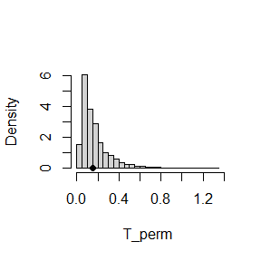

```r
hist(T_perm, main = "", freq = FALSE, breaks = "scott")
points(T_obs, 0, cex = 1, pch = 16) #observed T
```

# EX 8.2

Implement the bivariate Spearman rank correlation test for independence [255] as a permutation test. The Spearman rank correlation test statistic can be obtained from function cor with method = “spearman”. Compare the achieved significance level of the permutation test with the p-value reported by cor.test on the same samples.

由于题目没有给出数据，我们自行生成两组正态分布随机数据

```r
# 生成两个样本数据
set.seed(123)
x <- rnorm(30)
y <- rnorm(30)

# 计算原始样本的Spearman秩相关系数
spearman_stat <- cor(x, y, method = "spearman")

# 使用 cor.test 来获得 p 值
cor_test_result <- cor.test(x, y, method = "spearman")

# 置换检验
R <- 1000 # 置换次数
perm_stats <- numeric(R)

for (i in 1:R) {
  perm_stats[i] <- cor(x, sample(y), method = "spearman") # 随机置换y并计算Spearman相关系数
}

# 计算置换检验的 p 值
p_value_perm <- mean(abs(c(perm_stats, spearman_stat)) >= abs(spearman_stat))
cat("cor.test 的 p 值:", cor_test_result$p.value,"置换检验的 p 值:", p_value_perm, "\n")
```

```
## cor.test 的 p 值: 0.5294988 置换检验的 p 值: 0.5274725
```

# 第六次作业

# EX 9.3

Use the Metropolis-Hastings sampler to generate random variables from a standard Cauchy distribution. Discard the first 1000 of the chain, and compare the deciles of the generated observations with the deciles of the standard Cauchy distribution (see qcauchy or qt with df=1). Recall that a $Cauchy(\theta, \eta)$distribution has density function
$$f(x) = \frac{1}{\theta\pi(1 + [(x-\eta)/\theta]^2)}, \quad -\infty <
x < \infty$$

The standard Cauchy has the $Cauchy(\theta=1, \eta=0)$ density. (Note that the standard Cauchy density is equal to the Student t density with one degree of freedom.)

解答: 标准柯西分布的密度函数为：
$$f(x) =
\frac{1}{\pi(1 + x^2)}, \quad -\infty < x < \infty$$

```r
set.seed(123)
n <- 10000  # 总采样数
x <- numeric(n)  # 初始化样本存储向量
x[1] <- 0  # 初始化

for (i in 2:n) {
  y <- x[i - 1] + rnorm(1, mean = 0, sd = 1)  # 使用正态分布作为提议分布
  if (runif(1) < dcauchy(y) / dcauchy(x[i - 1])) {
    x[i] <- y
  } else {
    x[i] <- x[i - 1]
  }
}

samples <- x[(1000 + 1):n] # 去掉前1000个值

# 比较样本和理论柯西分布的分位数
cat("分位数为：",seq(0.1,0.9,0.1),"\n")
```

```
## 分位数为： 0.1 0.2 0.3 0.4 0.5 0.6 0.7 0.8 0.9
```

```r
cat("样本分位数：",quantile(samples, probs = seq(0.1, 0.9, by = 0.1)),"\n")
```

```
## 样本分位数： -2.817489 -1.402669 -0.7378453 -0.3335088 -0.01642563 0.3070602 0.7233017 1.372667 3.028368
```

```r
cat("理论分位数：",qcauchy(seq(0.1, 0.9, by = 0.1)))
```

```
## 理论分位数： -3.077684 -1.376382 -0.7265425 -0.3249197 0 0.3249197 0.7265425 1.376382 3.077684
```

# EX 9.8

This example appears in [40]. Consider the bivariate density

$$f(x, y) \propto \binom{n}{x} y^{x + a - 1} (1 - y)^{n - x + b - 1},
\quad x = 0, 1, \dots, n, \quad 0 \le y \le 1.$$

It can be shown (see e.g. [23]) that for fixed $a$, $b$, $n$, the conditional distributions are Binomial($n$, $y$) and Beta($x + a$, $n - x + b$). Use the Gibbs sampler to generate a chain with target joint density $f(x, y)$.

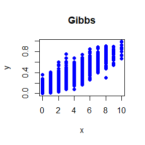

```r
set.seed(123)
n <- 10            # 总样本数
a <- 1
b <- 2             # Beta分布的参数a和b

# 初始化链
x <- numeric(1000)  # 迭代1000次
y <- numeric(1000)
x[1] <- rbinom(1, n, 0.5)  # 初始化x的值
y[1] <- rbeta(1, x[1] + a, n - x[1] + b)  # 初始化y的值

# Gibbs采样
for (i in 2:1000) {
  # 更新条件分布
  x[i] <- rbinom(1, size = n, prob = y[i - 1])
  y[i] <- rbeta(1, shape1 = x[i] + a, shape2 = n - x[i] + b)
}


x <- x[(100 + 1):1000]
y <- y[(100 + 1):1000]  # 去掉前100个数避免初始值影响

# 可视化生成样本的分布情况
plot(x, y, main = "Gibbs", pch = 16, col ="blue")
```

# 补充问题

For each of the above exercise, use the Gelman-Rubin method to monitor convergence of the chain, and run the chain until it converges approximately to the target distribution according to $\hat R$ < 1.2

一般Gelman-Rubin method需要重复实验3~5次，我们重复三次，计算三条链的总体方差和每条链的内部方差，比值和1.2比大小.

首先是EX 9.3：

```r
set.seed(123)
n <- 10000  # 总采样数
x <- numeric(n)  # 初始化样本存储向量
x[1] <- 0  # 初始化

for (i in 2:n) {
  y <- x[i - 1] + rnorm(1, mean = 0, sd = 1)  # 使用正态分布作为提议分布
  if (runif(1) < dcauchy(y) / dcauchy(x[i - 1])) {
    x[i] <- y
  } else {
    x[i] <- x[i - 1]
  }
}
c1 <- x[(1000 + 1):n] # 第一组



x <- numeric(n)  # 初始化样本存储向量
x[1] <- 0  # 初始化

for (i in 2:n) {
  y <- x[i - 1] + rnorm(1, mean = 0, sd = 1)  # 使用正态分布作为提议分布
  if (runif(1) < dcauchy(y) / dcauchy(x[i - 1])) {
    x[i] <- y
  } else {
    x[i] <- x[i - 1]
  }
}
c2 <- x[(1000 + 1):n] # 第二组



x <- numeric(n)  # 初始化样本存储向量
x[1] <- 0  # 初始化

for (i in 2:n) {
  y <- x[i - 1] + rnorm(1, mean = 0, sd = 1)  # 使用正态分布作为提议分布
  if (runif(1) < dcauchy(y) / dcauchy(x[i - 1])) {
    x[i] <- y
  } else {
    x[i] <- x[i - 1]
  }
}
c3 <- x[(1000 + 1):n] # 第三组

B <- (n-1000)/2*var(c(mean(c1), mean(c2), mean(c3)))
W <- 1/3*sum(var(c1), var(c2), var(c3))
R_hat <- (8999/9000*W+1/9000*B)/W
R_hat
```

```
## [1] 1.014332
```

说明此时$\hat R=1.014$确实小于1.2，认为链收敛。

再考虑EX 9.8

```r
set.seed(123)
n <- 10            # 总样本数
a <- 1
b <- 2             # Beta分布的参数a和b

# 初始化链
x <- numeric(1000)  # 迭代1000次
y <- numeric(1000)
x[1] <- rbinom(1, n, 0.5)  # 初始化x的值
y[1] <- rbeta(1, x[1] + a, n - x[1] + b)  # 初始化y的值

# Gibbs采样
for (i in 2:1000) {
  # 更新条件分布
  x[i] <- rbinom(1, size = n, prob = y[i - 1])
  y[i] <- rbeta(1, shape1 = x[i] + a, shape2 = n - x[i] + b)
}

x1 <- x[(100 + 1):1000]
y1 <- y[(100 + 1):1000]  # 去掉前100个数避免初始值影响



x <- numeric(1000)  # 迭代1000次
y <- numeric(1000)
x[1] <- rbinom(1, n, 0.5)  # 初始化x的值
y[1] <- rbeta(1, x[1] + a, n - x[1] + b)  # 初始化y的值

# Gibbs采样
for (i in 2:1000) {
  # 更新条件分布
  x[i] <- rbinom(1, size = n, prob = y[i - 1])
  y[i] <- rbeta(1, shape1 = x[i] + a, shape2 = n - x[i] + b)
}

x2 <- x[(100 + 1):1000]
y2 <- y[(100 + 1):1000]  # 去掉前100个数避免初始值影响



x <- numeric(1000)  # 迭代1000次
y <- numeric(1000)
x[1] <- rbinom(1, n, 0.5)  # 初始化x的值
y[1] <- rbeta(1, x[1] + a, n - x[1] + b)  # 初始化y的值

# Gibbs采样
for (i in 2:1000) {
  # 更新条件分布
  x[i] <- rbinom(1, size = n, prob = y[i - 1])
  y[i] <- rbeta(1, shape1 = x[i] + a, shape2 = n - x[i] + b)
}

x3 <- x[(100 + 1):1000]
y3 <- y[(100 + 1):1000]  # 去掉前100个数避免初始值影响

B <- 900/2*(var(c(mean(x1), mean(x2), mean(x3))) + var(c(mean(y1), mean(y2), mean(y3))))
W <- 1/3*(sum(var(x1), var(x2), var(x3)) + sum(var(y1), var(y2), var(y3)))
R_hat <- (899/900*W+1/900*B)/W
R_hat
```

```
## [1] 1.007375
```

显然此时$\hat R=1.007$也小于1.2，认为此时链也收敛。

# 证明平稳条件

对于状态 $s$ 和 $r$，不妨假设$s \neq r$ ，否则显然平稳条件成立。我们有：

$$K(s,r) f(s) = g(r \mid s) \alpha(s,r) f(s).$$

根据 $\alpha(s,r)$ 的定义，我们可以将其展开为：

$$K(s,r) f(s) = g(r \mid s) \min \left\{ \frac{f(r) g(s \mid r)}{f(s) g(r
\mid s)}, 1 \right\} f(s).$$

如果

$$\frac{f(s) g(r \mid s)}{f(r) g(s \mid r)} \leq 1,$$

则

$$\alpha(s,r) = \frac{f(r) g(s \mid r)}{f(s) g(r \mid s)},$$

因此

$$K(s,r) f(s) = g(r \mid s) \frac{f(r) g(s \mid r)}{f(s) g(r \mid s)} f(s)
= f(r) g(s \mid r) = K(r,s) f(r).$$

如果

$$\frac{f(s) g(r \mid s)}{f(r) g(s \mid r)} > 1,$$

则

$$\alpha(s,r) = 1,$$

因此

$$K(s,r) f(s) = g(r \mid s) f(s) = f(r) g(s \mid r) = K(r,s) f(r).$$

## 结论

通过验证细致平衡条件

$$K(s,r) f(s) = K(r,s) f(r),$$

我们证明了 Metropolis-Hastings 算法在连续情况下的平稳性。

# 第七次作业

# EX 11.3

1. Write a function to compute the $k$th term in
   $$\sum_{k=0}^{\infty} \frac{(-1)^k}{k! 2^k} \frac{\|a\|^{2k+2}}{(2k +
   1)(2k + 2)} \frac{\Gamma \left( \frac{d+1}{2} \right)\Gamma \left( k +
   \frac{3}{2} \right)}{ \Gamma \left( k +\frac{ d}{2} + 1 \right)},$$
   where $d \geq 1$ is an integer, $a$ is a vector in $\mathbb{R}^d$, and $\|\cdot\|$ denotes the Euclidean norm. Perform the arithmetic so that the coefficients can be computed for (almost) arbitrarily large $k$ and $d$. (This sum converges for all $a \in \mathbb{R}^d$).

使用lgamma函数避免gamma函数过大

```r
library(gsl)
# 计算第 k 项函数
kth_term <- function(k, d, a) {
  term <- (-1)^k / (factorial(k) * 2^k) * sqrt(sum(a^2))^(2 * k + 2) / ((2 * k + 1) * (2 * k + 2)) * exp(lgamma((d + 1) / 2) + lgamma(k + 3 / 2) - lgamma(k + d / 2 + 1))
  return(term)
}

# 对较大的k和d测试
d <- 400
a <- c(1, 2)
k <- 100
kth_term(k, d, a)
```

```
## [1] 1.400702e-204
```

发现可以计算出正确的结果

2. Modify the function so that it computes and returns the sum.

当加项小于1e-10的时候停止求和

```r
sum_series <- function(d, a, tol = 1e-10) {
  sum <- 0
  k <- 0
  repeat {
    term <- kth_term(k, d, a)
    sum <- sum + term
    if (abs(term) < tol) break
    k <- k + 1
  }
  return(sum)
}
```

3. Evaluate the sum when a = (1, 2)T .

取d = 100求和

```r
a <- c(1, 2)
d <- 100
result <- sum_series(d, a)
result
```

```
## [1] 0.3088054
```

# EX 11.5

Write a function to solve the equation

$$\frac{2 \Gamma \left( \frac{k}{2} \right)}{\sqrt{\pi (k - 1)} \Gamma
\left( \frac{k - 1}{2} \right)} \int_0^{c_{k-1}} \left( 1 + \frac{u^2}{k
- 1} \right)^{-\frac{k}{2}} du = \frac{2 \Gamma \left( \frac{k+1}{2}
\right)}{\sqrt{\pi k} \Gamma \left( \frac{k}{2} \right)} \int_0^{c_k}
\left( 1 + \frac{u^2}{k} \right)^{-\frac{k+1}{2}} du$$

for $a$, where

$$c_k = \sqrt{\frac{a^2 k}{k + 1 - a^2}}.$$

Compare the solutions with the points $A(k)$ in Exercise 11.4.

我们在k = 5时计算a的值：

```r
# 定义左侧的积分函数
left_integral <- function(k, c_k_minus_1) {
  integrand <- function(u) {
    (1 + u^2 / (k - 1))^(-k / 2)
  }
  integrate(integrand, lower = 0, upper = c_k_minus_1)$value
}

# 定义右侧的积分函数
right_integral <- function(k, c_k) {
  integrand <- function(u) {
    (1 + u^2 / k)^(-(k + 1) / 2)
  }
  integrate(integrand, lower = 0, upper = c_k)$value
}

# 定义 c_k 公式
c_k <- function(a, k) {
  sqrt((a^2 * k) / (k + 1 - a^2))
}

target_function <- function(a, k) {

  c_k_minus_1 <- c_k(a, k - 1)
  c_k_value <- c_k(a, k)

  # 计算左右两边的值
  left_value <- (2 * gamma(k / 2)) / (sqrt(pi * (k - 1)) * gamma((k - 1) / 2)) * left_integral(k, c_k_minus_1)
  right_value <- (2 * gamma((k + 1) / 2)) / (sqrt(pi * k) * gamma(k / 2)) * right_integral(k, c_k_value)

  # 返回左右差值
  left_value - right_value
}

# 这里区间取成0,1到sqrt(k)-0.05是为了保护分母
solve_a <- function(k, interval = c(0.1, sqrt(k)-0.05)) {
  uniroot(function(a) target_function(a, k), interval = interval)$root
}

# 在k=5时计算a的值
k_value <- 5
a_solution <- solve_a(k_value)
a_solution
```

```
## [1] 1.533564
```

# 补充问题

Suppose $T_1, \ldots, T_n$ are i.i.d. samples drawn from the exponential distribution with expectation $\lambda$. Those values greater than $\tau$ are not observed due to right censorship, so that the observed values are $Y_i = T_i I(T_i \leq \tau) + \tau I(T_i > \tau)$, $i = 1, \ldots, n$. Suppose $\tau = 1$ and the observed $Y_i$ values are as follows: 0.54, 0.48, 0.33, 0.43, 1.00, 1.00, 0.91, 1.00, 0.21, 0.85 Use the E-M algorithm to estimate $\lambda$, compare your result with the observed data MLE (note: $Y_i$ follows a mixture distribution)

```r
# 初始化数据
observed_Y <- c(0.54, 0.48, 0.33, 0.43, 1.00, 1.00, 0.91, 1.00, 0.21, 0.85)
tau <- 1
n <- length(observed_Y)

# 初始猜测的 lambda 值
lambda <- 1
tol <- 1e-6
max_iter <- 1000
log_likelihood_diff <- Inf
iteration <- 0

while (log_likelihood_diff > tol && iteration < max_iter) {
  iteration <- iteration + 1

  # E-step: 计算被截尾的 Y_i = 1 的缺失部分
  expected_T <- observed_Y
  censored_indices <- which(observed_Y == tau)

  if (length(censored_indices) > 0) {
    expected_T[censored_indices] <- tau + lambda
  }

  # M-step: 更新 lambda
  new_lambda <- mean(expected_T)

  # 检查收敛
  log_likelihood_diff <- abs(new_lambda - lambda)
  lambda <- new_lambda
}

# 输出结果
cat("使用EM算法估计得到的 lambda 值为:", 1/lambda, "\n")
```

```
## 使用EM算法估计得到的 lambda 值为: 1.037037
```

```r
# 使用直接观测数据的 MLE 估计
observed_mle_lambda <- mean(observed_Y)
cat("观测数据的 MLE lambda 值为:", 1/observed_mle_lambda, "\n")
```

```
## 观测数据的 MLE lambda 值为: 1.481481
```

可以发现使用EM算法估计的lambda值比直接估计的小很多，这也符合常理

# 第八次作业

# EX 11.7

Use the simplex algorithm to solve the following problem. Minimize 4x + 2y + 9z subject to

$$\begin{aligned}
2x + y + z &\leq 2, \\
x - y + 3z &\leq 3, \\
x \geq 0, y \geq 0, z &\geq 0.
\end{aligned}$$

```r
library(lpSolve)
# 定义目标函数的系数
objective <- c(4, 2, 9)  # 对应 4x + 2y + 9z

# 定义约束矩阵
constraints <- matrix(c(
  2, 1, 1,  # 2x + y + z
  1, -1, 3  # x - y + 3z
), nrow = 2, byrow = TRUE)

# 定义约束的右侧值
rhs <- c(2, 3)

# 定义约束的方向
direction <- c("<=", "<=")

# 求解线性规划问题 (最小化问题)
result <- lp("min", objective, constraints, direction, rhs, all.int = FALSE)

# 显示结果
cat("Optimal value of the objective function:", result$objval, "\n")
```

```
## Optimal value of the objective function: 0
```

```r
cat("Optimal values of x, y, z:", result$solution, "\n")
```

```
## Optimal values of x, y, z: 0 0 0
```

# Advanced R

## Page 204 EX 3

Use both for loops and lapply() to fit linear models to the mtcars using the formulas stored in this list:

formulas <- list( mpg ~ disp, mpg ~ I(1 / disp), mpg ~ disp + wt, mpg ~ I(1 / disp) + wt )

```r
formulas <- list(
  mpg ~ disp,
  mpg ~ I(1 / disp),
  mpg ~ disp + wt,
  mpg ~ I(1 / disp) + wt
)

# 创建一个空列表存储模型结果
models_for <- list()

# 使用 for 循环拟合模型
for (i in seq_along(formulas)) {
  models_for[[i]] <- lm(formulas[[i]], data = mtcars)
}
models_for
```

```
## [[1]]
##
## Call:
## lm(formula = formulas[[i]], data = mtcars)
##
## Coefficients:
## (Intercept)         disp
##    29.59985     -0.04122
##
##
## [[2]]
##
## Call:
## lm(formula = formulas[[i]], data = mtcars)
##
## Coefficients:
## (Intercept)    I(1/disp)
##       10.75      1557.67
##
##
## [[3]]
##
## Call:
## lm(formula = formulas[[i]], data = mtcars)
##
## Coefficients:
## (Intercept)         disp           wt
##    34.96055     -0.01772     -3.35083
##
##
## [[4]]
##
## Call:
## lm(formula = formulas[[i]], data = mtcars)
##
## Coefficients:
## (Intercept)    I(1/disp)           wt
##      19.024     1142.560       -1.798
```

```r
# 使用 lapply 拟合模型
models_lapply <- lapply(formulas, function(f) lm(f, data = mtcars))
models_lapply
```

```
## [[1]]
##
## Call:
## lm(formula = f, data = mtcars)
##
## Coefficients:
## (Intercept)         disp
##    29.59985     -0.04122
##
##
## [[2]]
##
## Call:
## lm(formula = f, data = mtcars)
##
## Coefficients:
## (Intercept)    I(1/disp)
##       10.75      1557.67
##
##
## [[3]]
##
## Call:
## lm(formula = f, data = mtcars)
##
## Coefficients:
## (Intercept)         disp           wt
##    34.96055     -0.01772     -3.35083
##
##
## [[4]]
##
## Call:
## lm(formula = f, data = mtcars)
##
## Coefficients:
## (Intercept)    I(1/disp)           wt
##      19.024     1142.560       -1.798
```

## EX 4

Fit the model mpg ~ disp to each of the bootstrap replicates of mtcars in the list below by using a for loop and lapply(). Can you do it without an anonymous function?

bootstraps <- lapply(1:10, function(i) { rows <- sample(1:nrow(mtcars), rep = TRUE) mtcars[rows, ] })

```r
set.seed(123)
bootstraps <- lapply(1:10, function(i) {
  rows <- sample(1:nrow(mtcars), rep = TRUE)
  mtcars[rows, ]
})

# 创建一个空列表存储模型结果
models_for <- list()

# 使用 for 循环拟合模型
for (i in seq_along(bootstraps)) {
  models_for[[i]] <- lm(mpg ~ disp, data = bootstraps[[i]])
}

# 打印第一个模型的摘要
summary(models_for[[1]])
```

```
##
## Call:
## lm(formula = mpg ~ disp, data = bootstraps[[i]])
##
## Residuals:
##    Min     1Q Median     3Q    Max
## -5.433 -2.814 -0.870  3.000  7.002
##
## Coefficients:
##              Estimate Std. Error t value Pr(>|t|)
## (Intercept) 29.598040   1.252594   23.63  < 2e-16 ***
## disp        -0.037978   0.005091   -7.46 2.58e-08 ***
## ---
## Signif. codes:  0 '***' 0.001 '**' 0.01 '*' 0.05 '.' 0.1 ' ' 1
##
## Residual standard error: 3.573 on 30 degrees of freedom
## Multiple R-squared:  0.6498, Adjusted R-squared:  0.6381
## F-statistic: 55.66 on 1 and 30 DF,  p-value: 2.581e-08
```

```r
# 定义一个用于拟合模型的函数
fit_model <- function(data) {
  lm(mpg ~ disp, data = data)
}

# 使用 lapply 调用预定义的函数
models_lapply_no_anon <- lapply(bootstraps, fit_model)

# 打印第一个模型的摘要
summary(models_lapply_no_anon[[1]])
```

```
##
## Call:
## lm(formula = mpg ~ disp, data = data)
##
## Residuals:
##    Min     1Q Median     3Q    Max
## -5.433 -2.814 -0.870  3.000  7.002
##
## Coefficients:
##              Estimate Std. Error t value Pr(>|t|)
## (Intercept) 29.598040   1.252594   23.63  < 2e-16 ***
## disp        -0.037978   0.005091   -7.46 2.58e-08 ***
## ---
## Signif. codes:  0 '***' 0.001 '**' 0.01 '*' 0.05 '.' 0.1 ' ' 1
##
## Residual standard error: 3.573 on 30 degrees of freedom
## Multiple R-squared:  0.6498, Adjusted R-squared:  0.6381
## F-statistic: 55.66 on 1 and 30 DF,  p-value: 2.581e-08
```

## EX 5

For each model in the previous two exercises, extract R2 using the function below.

rsq <- function(mod) summary(mod)$r.squared

```r
# 定义提取 R^2 的函数
rsq <- function(mod) summary(mod)$r.squared

# 使用 for 循环结果提取 R^2
r_squared_for <- sapply(models_for, rsq)

# 查看结果
r_squared_for
```

```
##  [1] 0.6497636 0.6820834 0.7530595 0.6101709 0.7226119 0.7533418 0.7311415
##  [8] 0.6293502 0.6554375 0.7238971
```

```r
# 使用 lapply 结果提取 R^2
r_squared_lapply <- sapply(models_lapply, rsq)

# 查看结果
r_squared_lapply
```

```
## [1] 0.7183433 0.8596865 0.7809306 0.8838038
```

```r
# 使用无匿名函数的 lapply 结果提取 R^2
r_squared_lapply_no_anon <- sapply(models_lapply_no_anon, rsq)

# 查看结果
r_squared_lapply_no_anon
```

```
##  [1] 0.6497636 0.6820834 0.7530595 0.6101709 0.7226119 0.7533418 0.7311415
##  [8] 0.6293502 0.6554375 0.7238971
```

## Page 213 EX 3

The following code simulates the performance of a t-test for non-normal data. Use sapply() and an anonymous function to extract the p-value from every trial.

trials <- replicate( 100, t.test(rpois(10, 10), rpois(7, 10)), simplify = FALSE )

```r
# 模拟 100 次 t 检验
trials <- replicate(
  100,
  t.test(rpois(10, 10), rpois(7, 10)),
  simplify = FALSE
)
# 提取每次试验的 p 值
p_values <- sapply(trials, function(trial) trial$p.value)

# 查看前几个 p 值
head(p_values)
```

```
## [1] 0.8079199 0.6655118 0.8277717 0.5348996 0.2117373 0.5286436
```

## EX 6

Implement a combination of Map() and vapply() to create an lapply() variant that iterates in parallel over all of its inputs and stores its outputs in a vector (or a matrix). What arguments should the function take?

```r
# 自定义函数，结合 Map() 和 vapply()
parallel_apply <- function(FUN, ..., FUN.VALUE) {
  # 使用 Map 并行应用函数到所有输入
  results <- Map(FUN, ...)

  # 使用 vapply 确保输出为指定类型的向量或矩阵
  vapply(results, identity, FUN.VALUE)
}

# 示例 1：两个输入的并行相加
# 定义输入列表
input1 <- list(1, 2, 3)
input2 <- list(4, 5, 6)

# 定义需要应用的函数
my_function <- function(a, b) a + b

# 调用自定义函数
result <- parallel_apply(my_function, input1, input2, FUN.VALUE = numeric(1))
print(result)  # 输出: [1] 5 7 9
```

```
## [1] 5 7 9
```

输出矩阵的实例

```r
# 定义输入列表
input1 <- list(1, 2, 3)
input2 <- list(4, 5, 6)

# 定义需要应用的函数，返回一个长度为2的向量
my_function <- function(a, b) c(a, b)

# 调用自定义函数
result <- parallel_apply(my_function, input1, input2, FUN.VALUE = numeric(2))
print(result)
```

```
##      [,1] [,2] [,3]
## [1,]    1    2    3
## [2,]    4    5    6
```

```r
# 输出：一个 2 行矩阵
#      [,1] [,2] [,3]
# [1,]    1    2    3
# [2,]    4    5    6
```

## Page 365 EX 4

4. Make a faster version of chisq.test() that only computes the chi-square test statistic when the input is two numeric vectors with no missing values. You can try simplifying chisq.test() or by coding from the mathematical definition (http://en. wikipedia.org/wiki/Pearson%27s_chi-squared_test).

```r
# 自定义快速卡方检验函数
fast_chisq_test <- function(x, y) {
  # 检查输入是否为数值向量，且无缺失值
  if (!is.numeric(x) || !is.numeric(y)) stop("Inputs must be numeric vectors.")
  if (anyNA(x) || anyNA(y)) stop("Inputs must not contain missing values.")

  # 构建二维列联表
  contingency_table <- table(x, y)

  # 计算行和、列和以及总和
  row_sums <- rowSums(contingency_table)
  col_sums <- colSums(contingency_table)
  total <- sum(contingency_table)

  # 计算期望值
  expected <- outer(row_sums, col_sums) / total

  # 计算卡方统计量
  observed <- as.numeric(contingency_table)
  expected <- as.numeric(expected)
  chisq_statistic <- sum((observed - expected)^2 / expected)

  # 返回卡方统计量
  return(chisq_statistic)
}

# 示例：测试代码
x <- c(1, 2, 1, 2, 1, 2, 1, 2, 1, 2)
y <- c(1, 1, 2, 2, 1, 1, 2, 2, 1, 2)
fast_chisq_test(x, y)
```

```
## [1] 0.4
```

```r
# 比较运行速度
set.seed(123)
x <- sample(1:3, 1e7, replace = TRUE)
y <- sample(1:3, 1e7, replace = TRUE)

# 原始 chisq.test
system.time({
  chisq_result <- chisq.test(x, y)$statistic
})
```

```
##    user  system elapsed
##    0.77    0.06    1.00
```

```r
# 快速实现 fast_chisq_test
system.time({
  fast_result <- fast_chisq_test(x, y)
})
```

```
##    user  system elapsed
##    0.64    0.00    0.71
```

```r
# 验证两者结果一致性
# 忽略名字属性
all.equal(unname(chisq_result), fast_result)  # TRUE
```

```
## [1] TRUE
```

## EX 5

Can you make a faster version of table() for the case of an input of two integer vectors with no missing values? Can you use it to speed up your chi-square test?

```r
fast_table <- function(x, y) {
  # 假设 x 和 y 都是整数向量，并且没有缺失值
  n <- max(length(x), length(y))

  # 直接计算二维频数表
  res <- matrix(0, nrow = max(x), ncol = max(y))

  for(i in seq_len(n)) {
    res[x[i], y[i]] <- res[x[i], y[i]] + 1
  }

  return(res)
}

fast_chisq_test <- function(x, y) {
  # 计算快速频次表
  freq_table <- fast_table(x, y)

  # 计算卡方统计量
  expected <- outer(rowSums(freq_table), colSums(freq_table), "*") / sum(freq_table)
  chisq_stat <- sum((freq_table - expected)^2 / expected)

  return(chisq_stat)
}

# 验证结果的一致性
chisq_result <- chisq.test(x, y)$statistic
fast_result <- fast_chisq_test(x, y)
all.equal(unname(chisq_result), fast_result)
```

```
## [1] TRUE
```

# 第九次作业

# EX 9.8

The bivariate density is defined as follows:

$$f(x, y) \propto {n\choose k} \cdot y^{x+a-1} \cdot (1-y)^{n-x+b-1},
\quad x = 0, 1, \ldots, n, \quad 0 \leq y \leq 1.$$

For fixed parameters $a$, $b$, and $n$: - The conditional distribution of $x | y$ is $\text{Binomial}(n, y)$. - The conditional distribution of $y | x$ is $\text{Beta}(x + a, n - x + b)$.

We will use the Gibbs sampler to generate a chain targeting this joint density.

```r
library(Rcpp)
```

```r
library(ggplot2)
# 使用Rcpp实现Gibbs采样器
dir_cpp <- 'E:/Rstudio/R_project/Rcpp/'
sourceCpp(paste0(dir_cpp,"gibbs_sampler.cpp"))

# 参数设置
set.seed(123)
a <- 2; b <- 2
n <- 10
num_iter <- 10000
gibbs_chain <- gibbs_sampler(num_iter, a, b, n, 0.5)
gibbs_df <- data.frame(iter = 1:num_iter, x = gibbs_chain[, 1], y = gibbs_chain[, 2])

ggplot(gibbs_df, aes(x = x)) +
  geom_histogram(color = "black", fill = "blue", bins = 20, alpha = 0.7) +
  labs(title = "样本直方图：x", x = "x", y = "频率")

ggplot(gibbs_df, aes(x = y)) +
  geom_histogram(color = "black", fill = "red", bins = 20, alpha = 0.7) +
  labs(title = "样本直方图：y", x = "y", y = "频率")
```

[output not shown]

Compare the corresponding generated random numbers with those by the R function you wrote using the function “qqplot”.

我们将使用R写一个与Rcpp类似的Gibbs采样器

```r
source(paste0(dir_cpp,'GibbsR.R'))
# 参数设置
set.seed(123)
num_iter <- 10000
a <- 2; b <- 2; n <- 10; y_init <- 0.5

# 运行R版本的Gibbs采样器
gibbs_chain_r <- gibbs_sampler_r(num_iter, a, b, n, y_init)
```

使用qqplot比较两种生成结果的相似性

```r
gibbs_chain_cpp <- gibbs_sampler(num_iter, a, b, n, y_init)
gibbs_chain_cpp <- data.frame(x = gibbs_chain_cpp[, 1], y = gibbs_chain_cpp[, 2])

# 比较x的随机数
qqplot(
  gibbs_chain_r$x, gibbs_chain_cpp$x,
  main = "x Q-Q Plot",
  xlab = "R",
  ylab = "Rcpp",
  pch = 20, col = "blue"
)
abline(0, 1, col = "red", lwd = 2)

# 比较y的随机数
qqplot(
  gibbs_chain_r$y, gibbs_chain_cpp$y,
  main = "y Q-Q Plot",
  xlab = "R",
  ylab = "Rcpp",
  pch = 20, col = "blue"
)
abline(0, 1, col = "red", lwd = 2)
```

[output not shown]

Campare the computation time of the two functions with the function “microbenchmark”

```r
# 加载 microbenchmark 包
library(microbenchmark)

# 设置参数
num_iter <- 10000
a <- 2; b <- 2; n <- 10; y_init <- 0.5

# 测试性能
benchmark_results <- microbenchmark(
  R_version = gibbs_sampler_r(num_iter, a, b, n, y_init),
  Rcpp_version = gibbs_sampler(num_iter, a, b, n, y_init),
  times = 10 # 每个函数运行10次
)

# 显示结果
print(summary(benchmark_results)[, c("expr", "min", "median", "mean", "max")])

# 可视化性能比较
boxplot(benchmark_results, main = "Performance Comparison", ylab = "Execution Time (ns)")
```

[output not shown]